# Exploratory Data Analysis - Red Wine Quality

### Other correlations to Consider

**Correlation Matrix**

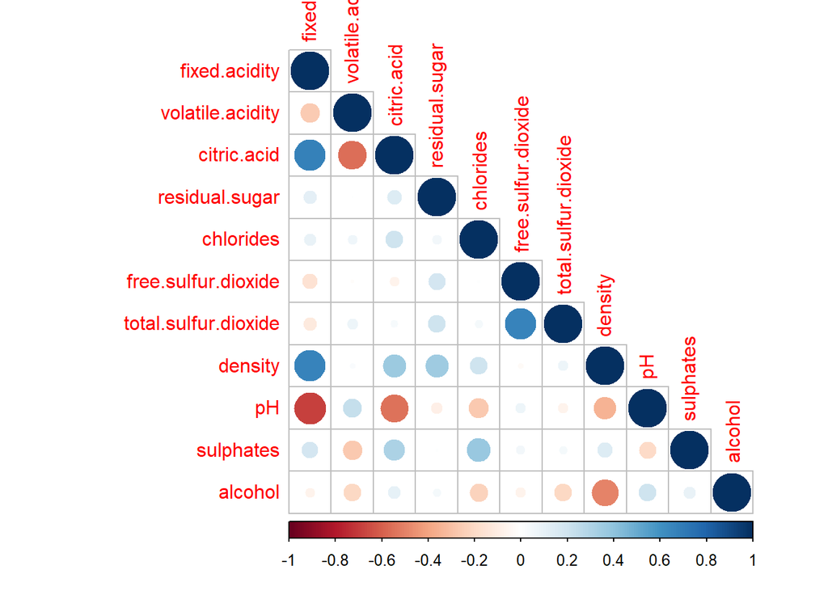

**Correlation of variables calculated to further explore.**

```
## fixed.acidity vs. density      fixed.acidity vs. pH        citric.acid vs. pH
##                 0.6747701                -0.7063602                -0.5387327
##   acids citric vs. fixed  acids citric vs. volatile       Alcohol vs. density
##                 0.6210402                -0.5668516                -0.4937366
##        SO2 free vs. total
##                 0.7390765
```

**Correlation plots to explore.**  
Fixed Acidity vs Density.

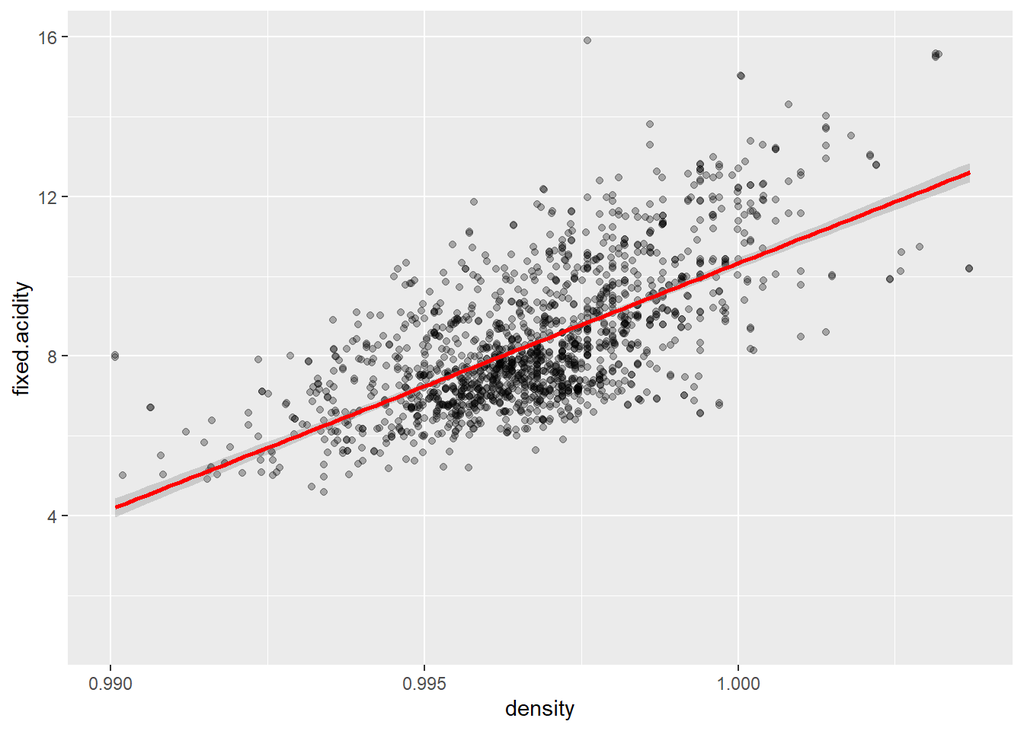

Fixed Acidity vs pH.

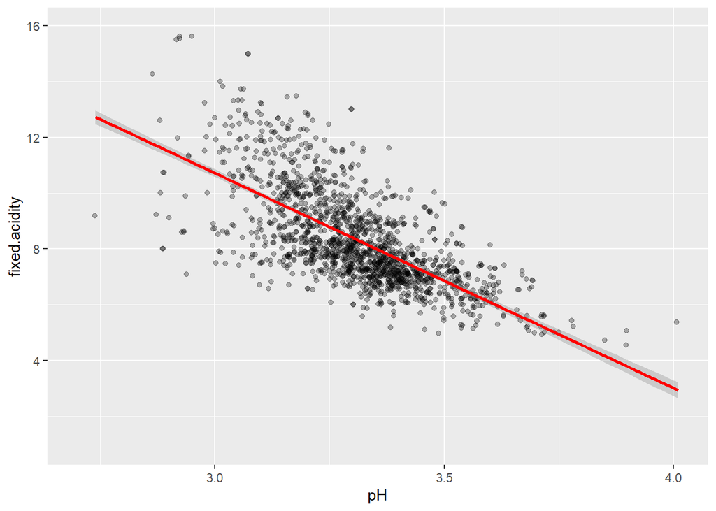

Citric acid vs pH.

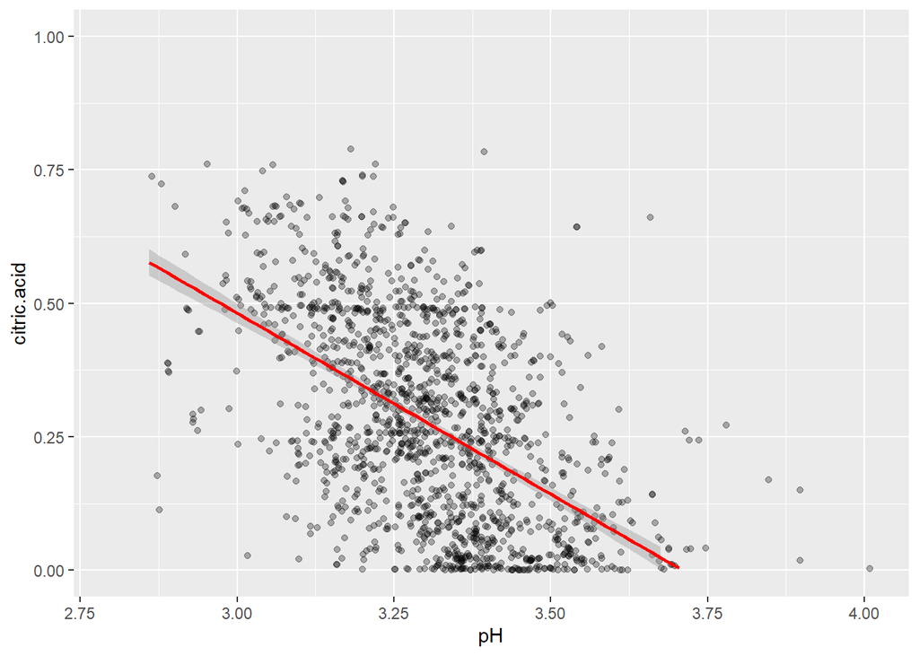

Citric Acid vs Fixed Acidity.

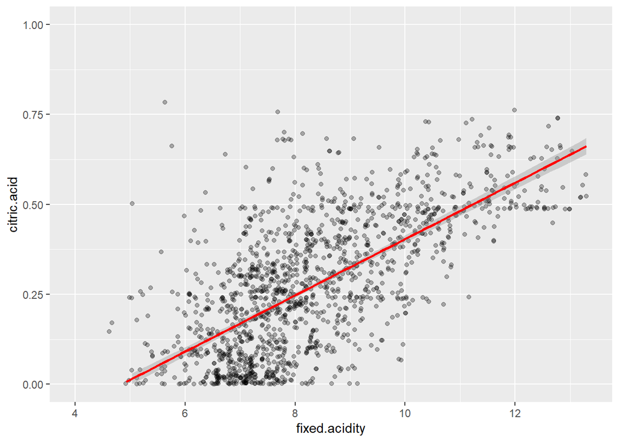

Citric Acid vs Volatile Acidity.

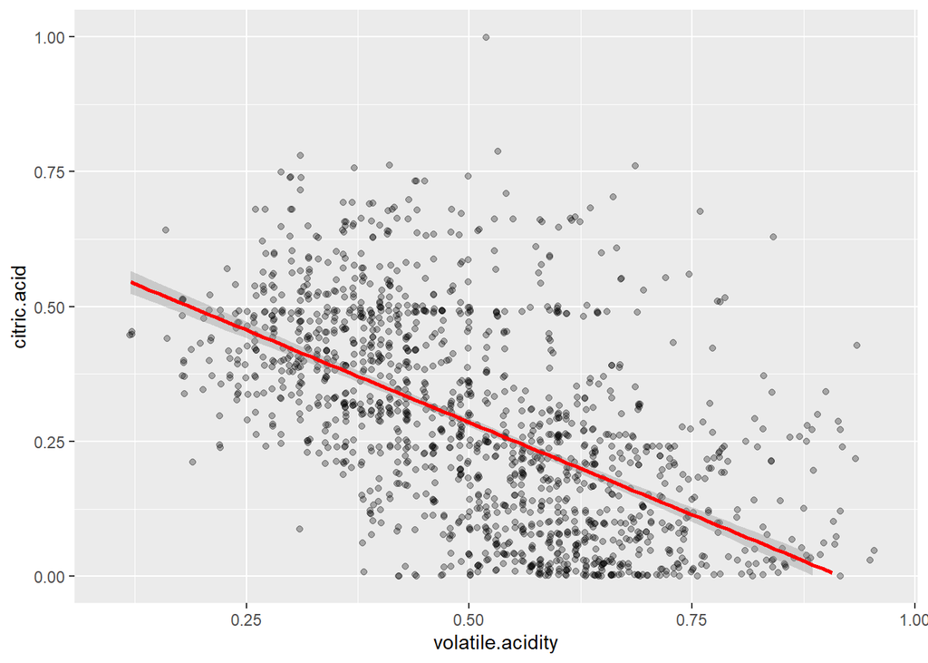

Alcohol vs. Density.

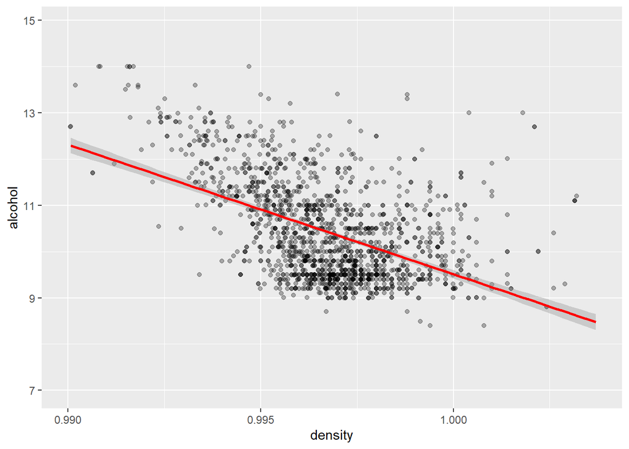

Sulfur Dioxide: Free vs. Total.

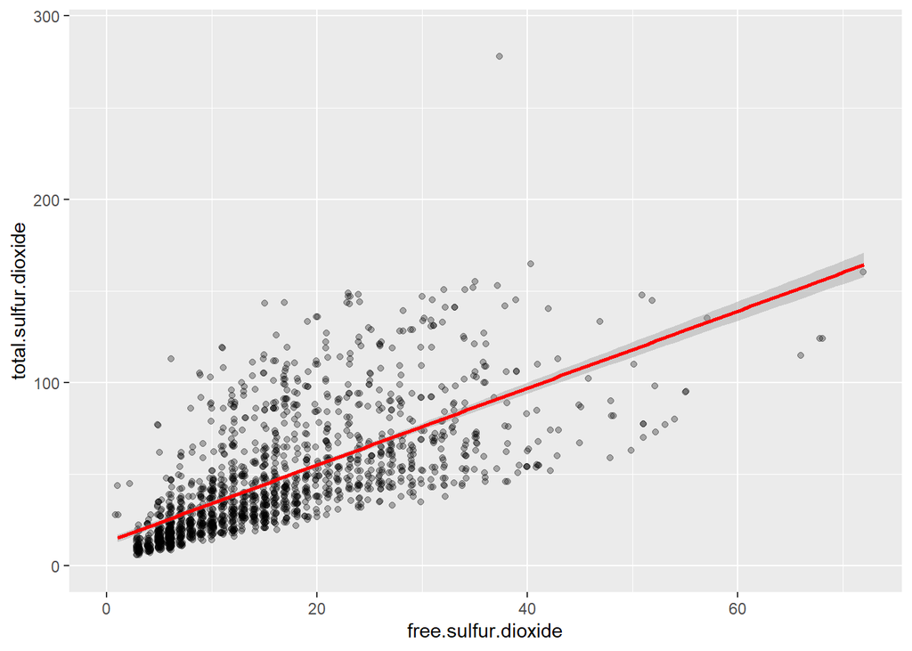

### Bivariate Analysis

**Talk about some of the relationships you observed in this part of the investigation. How did the feature(s) of interest vary with other features in the dataset?**

There are a few attributes exhibit some trends that look promising to be used to predict quality.  
* Quality is positively correlated with alcohol, citric acid, sulphates, and fixed acidity.  
* Quality is negatively correlated with volatile acidity, chlorides, density, and total sulfur dioxide.

We can summarize these relations in the following table:

[output not shown]

- ‘~’ means the attribute exhibits no clear trend with quality
- ‘-’ means the attribute is negatively correlated with quality
- ‘+’ means the attribute is positively correlated with quality

**Did you observe any interesting relationships between the other features (not the main feature(s) of interest)?**  
There are a few attributes that are correlated based on physical and chemical principles:

- Fixed acidity and density are positively correlated because the main fixed acids in wine, tartaric acid, has a higher density than water, therefore wines that contain more tartaric acid have a higher density.
- Fixed acidity and pH are negatively correlated because higher concentration of fixed acidity makes the wine more acidic, therefore the wine has a lower pH.
- Citric acid and pH are negatively correlated because higher concentration of citric acid, which is non-volatile, makes the wine more acidic, therefore the wine has a lower pH.
- Fixed acidity and citric acid are positively correlated because the fixed acidity includes citric acid.
- Citric acid and volatile acidity are negatively correlated because during the fermentation process the oxygen in wine is kept to a minimum which contributes to volatile acidity which ruins the wine. Citric acid is used to supplement the fermentation process in wine.
- Density and alcohol are negatively correlated because alcohol has a lower density than water, therefore wines that contain more alcohol have a lower density.
- Total sulfur dioxide and free sulfur dioxide are positively correlated because total sulfur dioxide includes free sulfur dioxide.

**What was the strongest relationship you found?** Observing from the plot, alcohol has the strongest relationship with quality.

# 4. MultiVariate Exploration

### Multivariate Plots

The scatter plots are facet wraped by rating. Graphs for four variables citric.acid, fixed.acidity, sulphates, and alcohol which show high correlations with quality. Other variables that affect quality are fixed acidity, pH, and density.

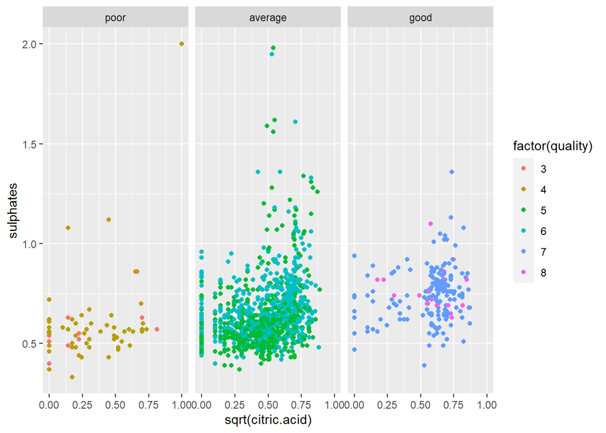

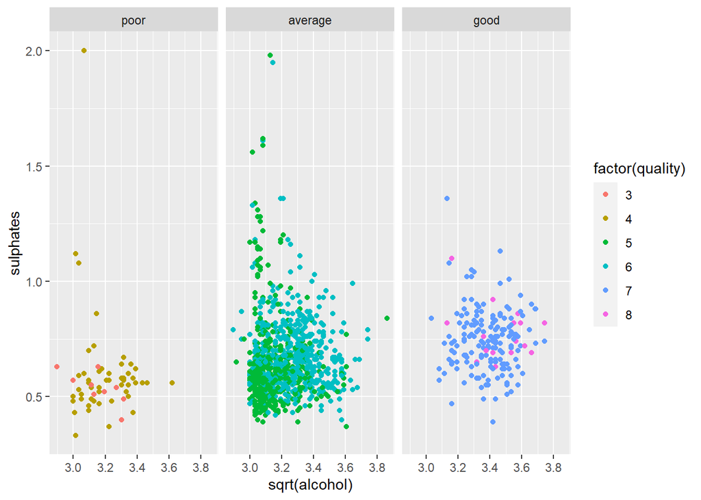

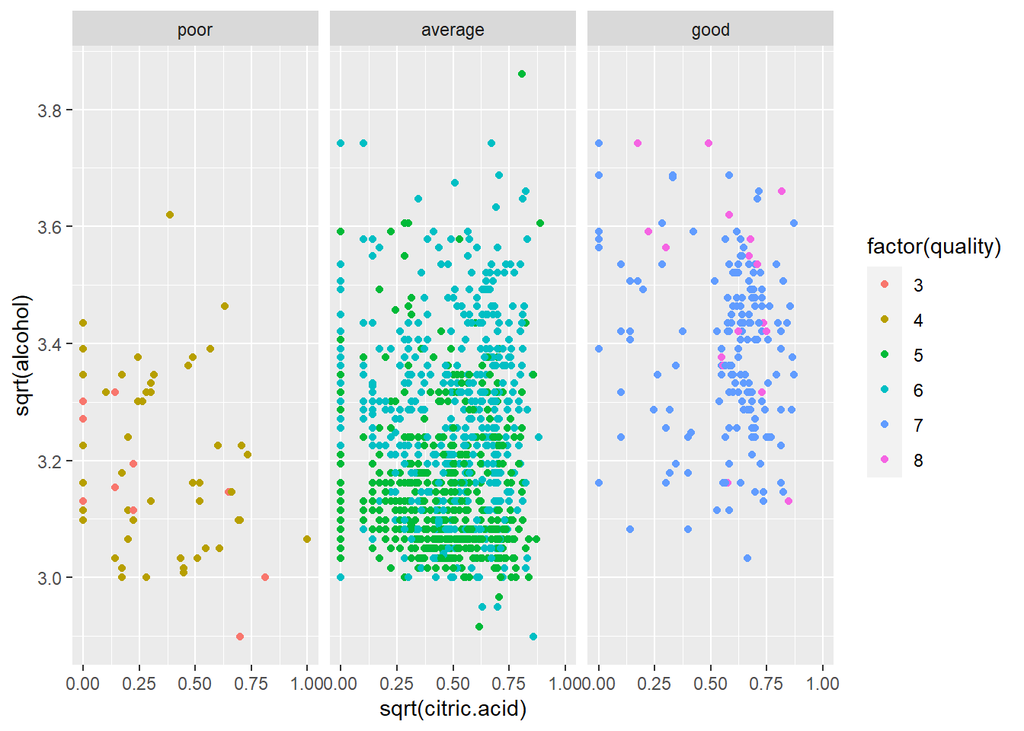

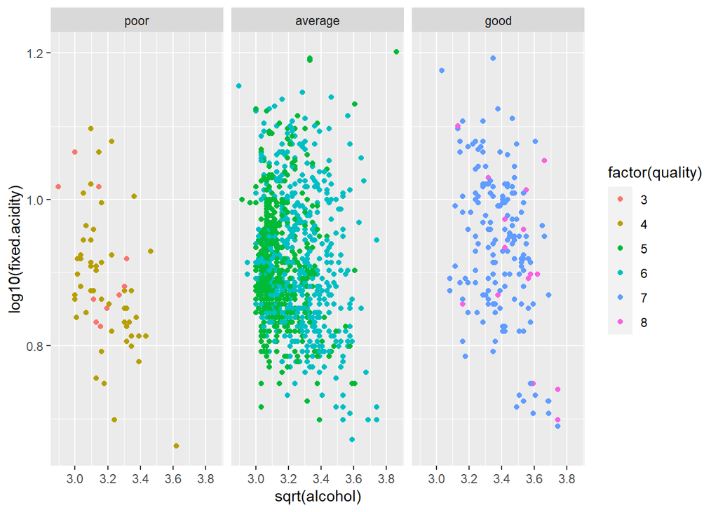

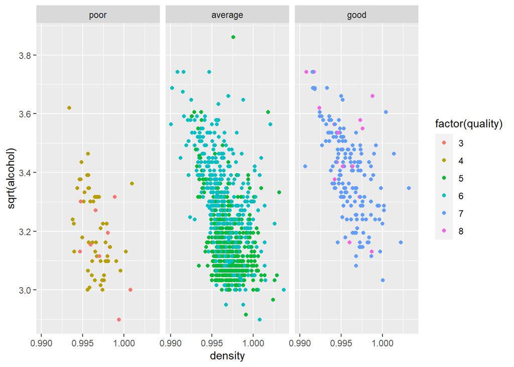

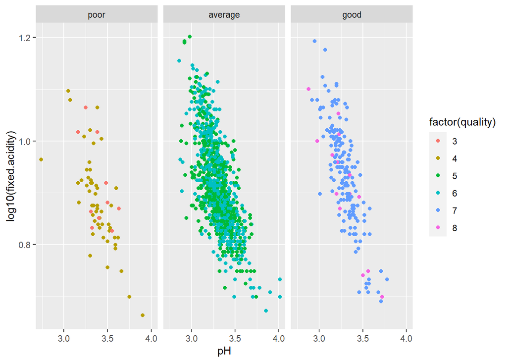

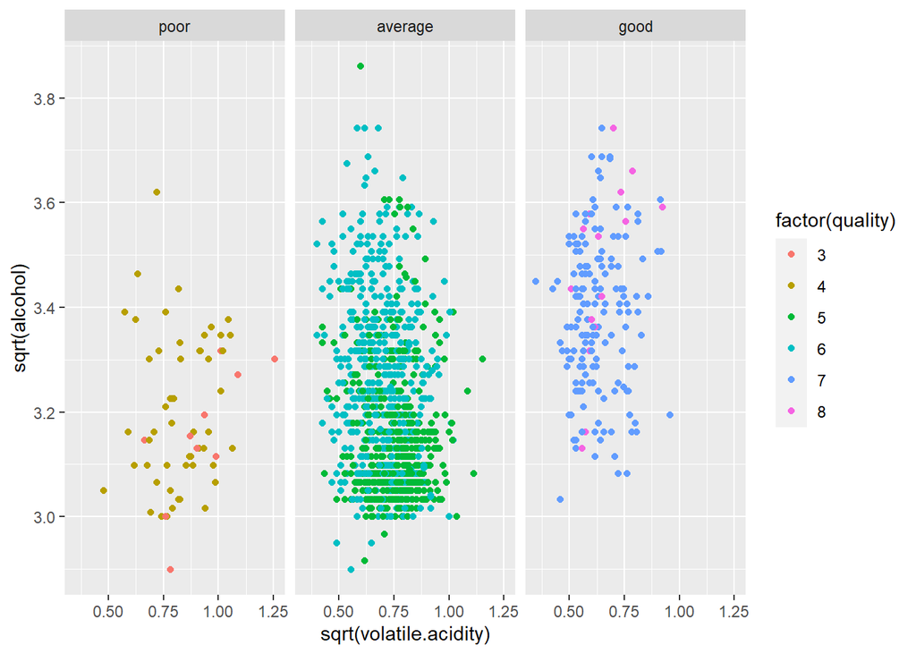

### Linear Model

Linear multivariable model was created to predict the wine quality based on chemical properties.

- First model I will only look at the most promising attribute alcohol from univariate exploration section.
- Second model I will add the attributes that exhibit a clear trend with quality from the bivariate exploration section besides alcohol.
- Third model I will add all the rest variables.

```
##
## Calls:
## m1: lm(formula = I(quality) ~ I(sqrt(alcohol)), data = red_wine)
## m2: lm(formula = I(quality) ~ I(sqrt(alcohol)) + sqrt(volatile.acidity) +
##     sulphates + sqrt(total.sulfur.dioxide) + sqrt(citric.acid) +
##     log10(fixed.acidity) + log10(chlorides) + density, data = red_wine)
## m3: lm(formula = I(quality) ~ I(sqrt(alcohol)) + sqrt(volatile.acidity) +
##     sulphates + sqrt(total.sulfur.dioxide) + sqrt(citric.acid) +
##     log10(fixed.acidity) + log10(chlorides) + density + log10(residual.sugar) +
##     sqrt(free.sulfur.dioxide) + pH, data = red_wine)
##
## =====================================================================
##                                   m1           m2           m3
## ---------------------------------------------------------------------
##   (Intercept)                   -2.024***    20.442       20.866
##                                 (0.354)     (14.999)     (22.744)
##   I(sqrt(alcohol))               2.376***     1.781***     1.750***
##                                 (0.110)      (0.131)      (0.178)
##   sqrt(volatile.acidity)                     -1.636***    -1.567***
##                                              (0.177)      (0.179)
##   sulphates                                   0.853***     0.853***
##                                              (0.108)      (0.112)
##   sqrt(total.sulfur.dioxide)                 -0.022**     -0.048***
##                                              (0.008)      (0.012)
##   sqrt(citric.acid)                          -0.188       -0.165
##                                              (0.113)      (0.116)
##   log10(fixed.acidity)                        1.194***     0.807
##                                              (0.334)      (0.526)
##   log10(chlorides)                           -0.471***    -0.531***
##                                              (0.133)      (0.136)
##   density                                   -21.377      -20.593
##                                             (15.043)     (23.209)
##   log10(residual.sugar)                                    0.177
##                                                           (0.147)
##   sqrt(free.sulfur.dioxide)                                0.050*
##                                                           (0.020)
##   pH                                                      -0.292
##                                                           (0.200)
## ---------------------------------------------------------------------
##   R-squared                      0.227        0.352        0.356
##   N                           1599         1599         1599
## =====================================================================
##   Significance: *** = p < 0.001; ** = p < 0.01; * = p < 0.05
```

The most promising attribute alcohol alone has R-squared value of 0.227. By adding the other 7 promsing attributes, R-squared value is a 1.55 times better becoming 0.352. But adding the remaining 3 attributes only increases the R-squared value by .004 to 0.356.

### Multivariate Analysis

**Talk about some of the relationships you observed in this part of the investigation. Were there features that trengthened each other in terms of looking at your feature(s) of interest?**

High alcohol contents with sulphate concentrations above 0.5 and citric acid above 0.5 with a pH < 3.5 seems to produce a better wine.

**Were there any interesting or surprising interactions between features?**  
Fixed acididty and pH had a stronger negative correlation than others.

**What was the strongest relationship you found?**  
The strongest relationship is the correlation between alcohol and quality.

**OPTIONAL: Did you create any models with your dataset? Discuss the strengths and limitations of your model.**

I created three linear models to predict the output attribute quality. The strength of the model is that it is a simple linear model and it is easy to interpret. Due to the limitation of the dataset, only physical and chemical attributes are available, and other import attributes, such as price, color, smell, etc are missing. The other attributes may influence the quality values to a large extent.

# 5. Final Plots

### Plot One

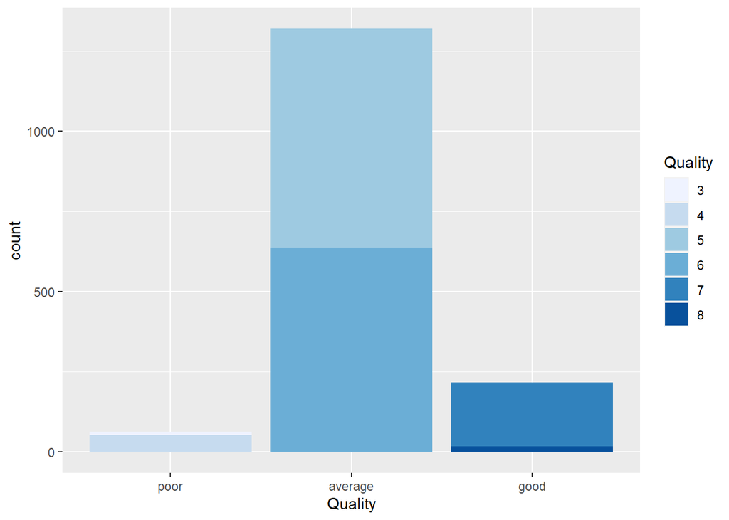

We can see the majority of the wines have a quality level of 5-6 which I consider average with very few wines in either extremes (3 or 8).

### Plot Two

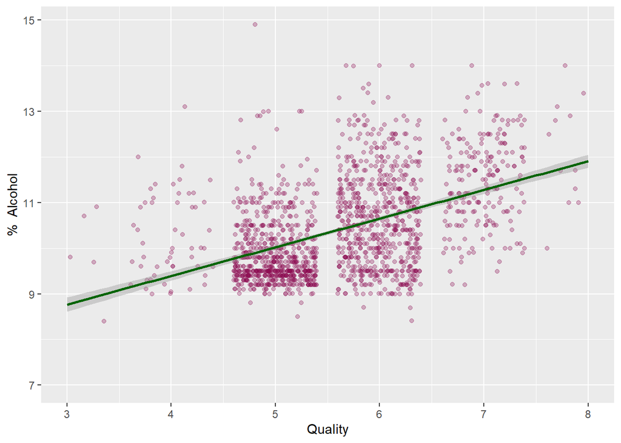

From the above plot it is clear that wine quality increases with % of alcohol in it. Interestingly the alcohol percentage of higher quality wines( quality> 6) increased with quality but some lower quality wines do not have the lowest alcohol percentage.

### Plot Three

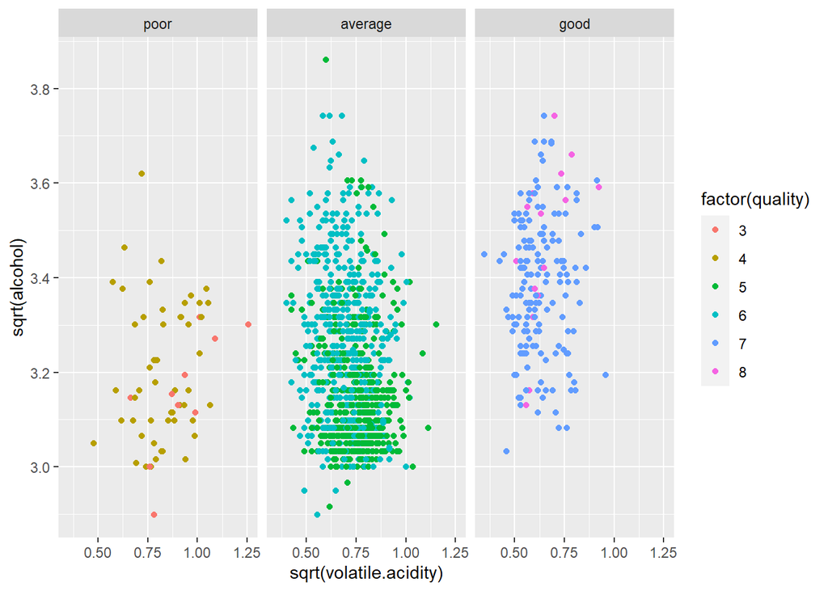

The above plots include all wines, some things that can be inferred from this plot are:

- High volatile acidity, with few exceptions, kept wine quality down.
- A combination of high alcohol content and low volatile acidity produced better wines.

# 6. Reflection

This dataset has 11 physicochemical properties of 1599 red wines. I read the information about each property so I understood the overall implications as I investigated the dataset further. After looking at the distributions of some variables, I examined the relationship between two and, eventually, three-variable combinations.

Wine quality depends on many features, through this exploratory data analysis I was able to relate some of the key factors like alcohol content, sulphates, and volatile acidity. The graphs adequately illustrate the factors that make good wines ‘good’ and poor wines ‘poor’.

In this data, my main struggle was to get a higher confidence level when predicting factors that are responsible for the production of good quality of wines. As the data was very centralized towards the ‘Average’ quality, this dataset did not have enough data on the extreme edges to accurately build a model that can predict the quality of a wine.

In the future, perhaps I can obtain a more robust dataset about Red Wines in order to build a more models. I believe by incorporating other types of attributes, such as price, color and smell, a better model can be built to predict the quality of wine.